# ANLY 512 - Problem Set 2

Anscombe’s quartet

Xiaowei Wan

2017-09-24

## Objectives

The objectives of this problem set is to orient you to a number of activities in `R`. And to conduct a thoughtful exercise in appreciating the importance of data visualization. For each question create a code chunk or text response that completes/answers the activity or question requested. Finally, upon completion name your final output `.html` file as: `YourName_ANLY512-Section-Year-Semester.html` and upload it to the “Problem Set 2” assignmenet on Moodle.

## Questions

1. Anscombes quartet is a set of 4 $x,y$ data sets that were published by *Francis Anscombe* in a 1973 paper [*Graphs in statistical analysis*](https://www.jstor.org/stable/2682899?seq=1#page_scan_tab_contents). For this first question load the `anscombe` data that is part of the `library(datasets)` in `R`. And assign that data to a new object called `data`.

```r
data <- anscombe
```

2. Summarise the data by calculating the mean, variance, for each column and the correlation between each pair (eg. x1 and y1, x2 and y2, etc) (Hint: use the `fBasics()` package!)

```r
# assign variables x1, x2, x3, x4, y1, y2, y3, y4
x1 <- data$x1
x2 <- data$x2
x3 <- data$x3
x4 <- data$x4
y1 <- data$y1
y2 <- data$y2
y3 <- data$y3
y4 <- data$y4
# mean and variance of x1
mean(x1)
```

```
## [1] 9
```

```r
var(x1)
```

```
## [1] 11
```

```r
# mean and variance of x2
mean(x2)
```

```
## [1] 9
```

```r
var(x2)
```

```
## [1] 11
```

```r
# mean and variance of x3
mean(x3)
```

```
## [1] 9
```

```r
var(x3)
```

```
## [1] 11
```

```r
# mean and variance of x4
mean(x4)
```

```
## [1] 9
```

```r
var(x4)
```

```
## [1] 11
```

```r
# mean and variance of y1
mean(y1)
```

```
## [1] 7.500909
```

```r
var(y1)
```

```
## [1] 4.127269
```

```r
# mean and variance of y2
mean(y2)
```

```
## [1] 7.500909
```

```r
var(y2)
```

```
## [1] 4.127629
```

```r
# mean and variance of y3
mean(y3)
```

```
## [1] 7.5
```

```r
var(y3)
```

```
## [1] 4.12262
```

```r
# mean and variance of y4
mean(y4)
```

```
## [1] 7.500909
```

```r
var(y4)
```

```
## [1] 4.123249
```

```r
library("fBasics")
correlationTest(x1, y1)
```

```
##
## Title:
##  Pearson's Correlation Test
##
## Test Results:
##   PARAMETER:
##     Degrees of Freedom: 9
##   SAMPLE ESTIMATES:
##     Correlation: 0.8164
##   STATISTIC:
##     t: 4.2415
##   P VALUE:
##     Alternative Two-Sided: 0.00217
##     Alternative      Less: 0.9989
##     Alternative   Greater: 0.001085
##   CONFIDENCE INTERVAL:
##     Two-Sided: 0.4244, 0.9507
##          Less: -1, 0.9388
##       Greater: 0.5113, 1
##
## Description:
##  Sun Sep 24 13:37:38 2017
```

```r
correlationTest(x2, y2)
```

```
##
## Title:
##  Pearson's Correlation Test
##
## Test Results:
##   PARAMETER:
##     Degrees of Freedom: 9
##   SAMPLE ESTIMATES:
##     Correlation: 0.8162
##   STATISTIC:
##     t: 4.2386
##   P VALUE:
##     Alternative Two-Sided: 0.002179
##     Alternative      Less: 0.9989
##     Alternative   Greater: 0.001089
##   CONFIDENCE INTERVAL:
##     Two-Sided: 0.4239, 0.9506
##          Less: -1, 0.9387
##       Greater: 0.5109, 1
##
## Description:
##  Sun Sep 24 13:37:38 2017
```

```r
correlationTest(x3, y3)
```

```
##
## Title:
##  Pearson's Correlation Test
##
## Test Results:
##   PARAMETER:
##     Degrees of Freedom: 9
##   SAMPLE ESTIMATES:
##     Correlation: 0.8163
##   STATISTIC:
##     t: 4.2394
##   P VALUE:
##     Alternative Two-Sided: 0.002176
##     Alternative      Less: 0.9989
##     Alternative   Greater: 0.001088
##   CONFIDENCE INTERVAL:
##     Two-Sided: 0.4241, 0.9507
##          Less: -1, 0.9387
##       Greater: 0.511, 1
##
## Description:
##  Sun Sep 24 13:37:38 2017
```

```r
correlationTest(x4, y4)
```

```
##
## Title:
##  Pearson's Correlation Test
##
## Test Results:
##   PARAMETER:
##     Degrees of Freedom: 9
##   SAMPLE ESTIMATES:
##     Correlation: 0.8165
##   STATISTIC:
##     t: 4.243
##   P VALUE:
##     Alternative Two-Sided: 0.002165
##     Alternative      Less: 0.9989
##     Alternative   Greater: 0.001082
##   CONFIDENCE INTERVAL:
##     Two-Sided: 0.4246, 0.9507
##          Less: -1, 0.9388
##       Greater: 0.5115, 1
##
## Description:
##  Sun Sep 24 13:37:38 2017
```

3. Create scatter plots for each $x, y$ pair of data.

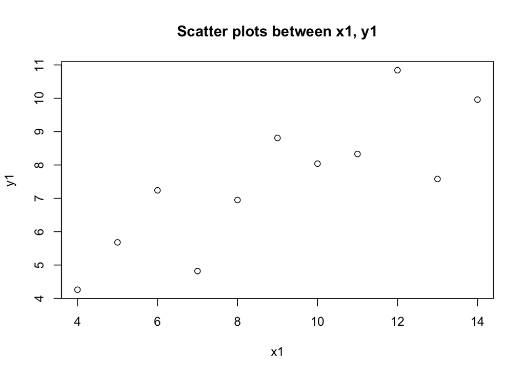

```r
plot(x1, y1, main="Scatter plots between x1, y1")
```

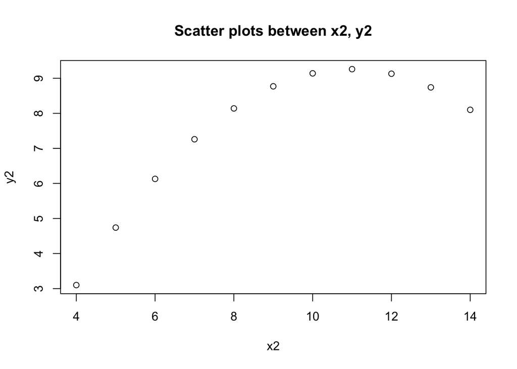

```r
plot(x2, y2, main="Scatter plots between x2, y2")
```

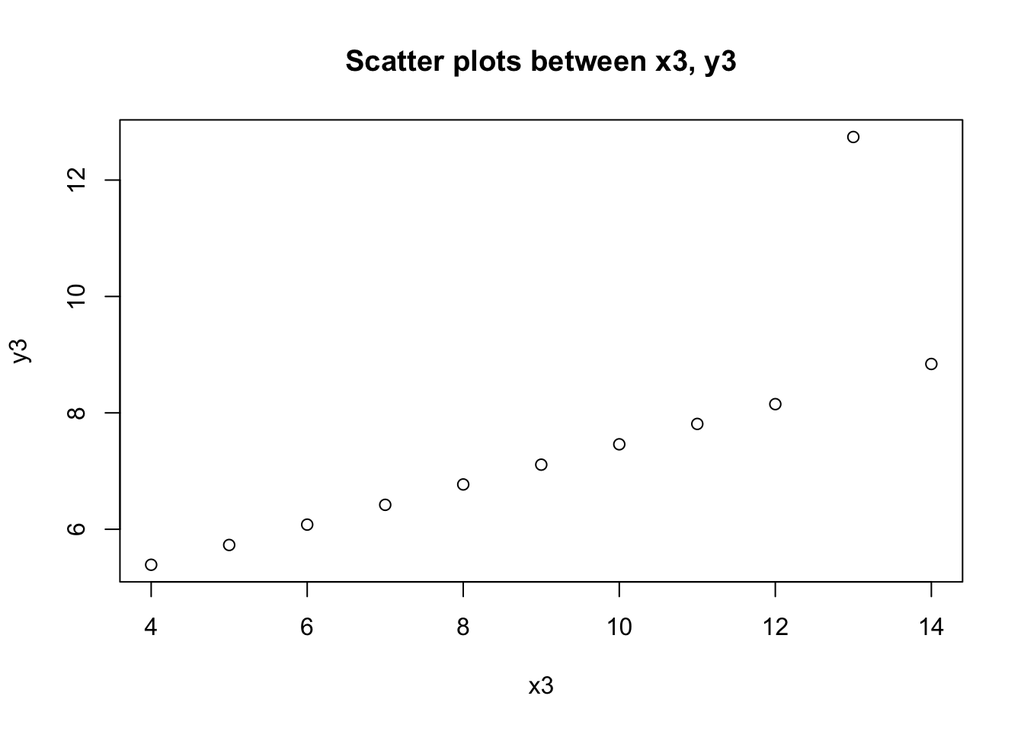

```r
plot(x3, y3, main="Scatter plots between x3, y3")
```

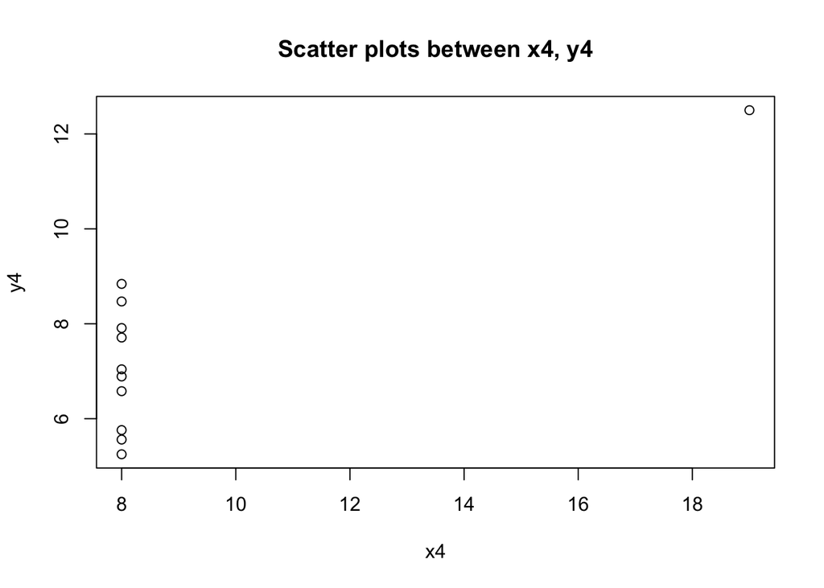

```r
plot(x4, y4, main="Scatter plots between x4, y4")
```

4. Now change the symbols on the scatter plots to solid circles and plot them together as a 4 panel graphic

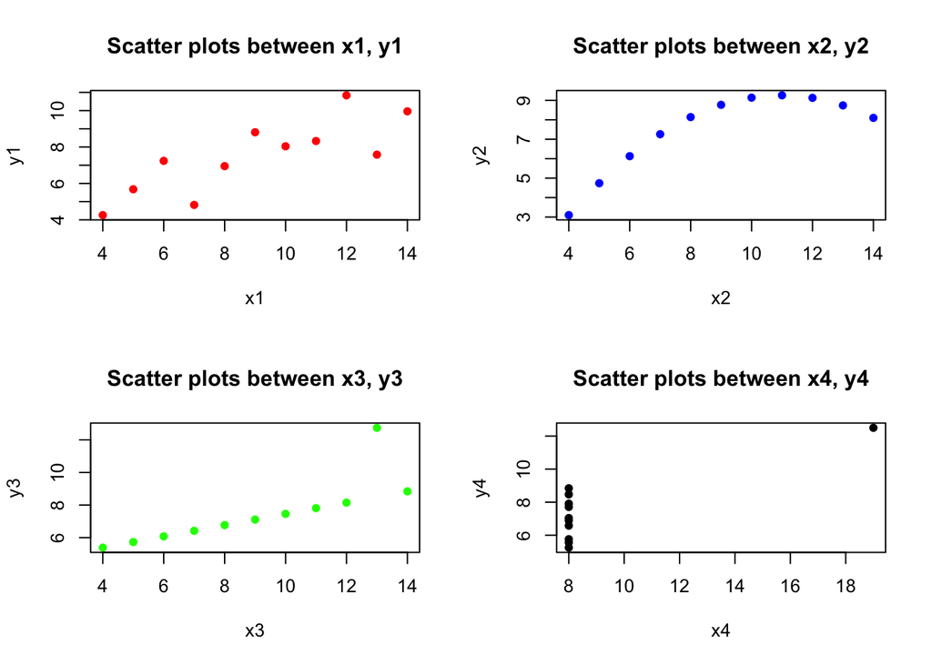

```r
par(mfrow=c(2,2))
plot(x1, y1, main="Scatter plots between x1, y1", pch=16, col="red")
plot(x2, y2, main="Scatter plots between x2, y2", pch=16, col="blue")
plot(x3, y3, main="Scatter plots between x3, y3", pch=16, col="green")
plot(x4, y4, main="Scatter plots between x4, y4", pch=16, col="black")
```

5. Now fit a linear model to each data set using the `lm()` function.

```r
# linear model between x1 ~ y1
lm_1 <- lm(y1 ~ x1)
summary(lm_1)
```

```
##
## Call:
## lm(formula = y1 ~ x1)
##
## Residuals:
##      Min       1Q   Median       3Q      Max
## -1.92127 -0.45577 -0.04136  0.70941  1.83882
##
## Coefficients:
##             Estimate Std. Error t value Pr(>|t|)
## (Intercept)   3.0001     1.1247   2.667  0.02573 *
## x1            0.5001     0.1179   4.241  0.00217 **
## ---
## Signif. codes:  0 '***' 0.001 '**' 0.01 '*' 0.05 '.' 0.1 ' ' 1
##
## Residual standard error: 1.237 on 9 degrees of freedom
## Multiple R-squared:  0.6665, Adjusted R-squared:  0.6295
## F-statistic: 17.99 on 1 and 9 DF,  p-value: 0.00217
```

```r
# linear model between x2 ~ y2
lm_2 <- lm(y2 ~ x2)
summary(lm_2)
```

```
##
## Call:
## lm(formula = y2 ~ x2)
##
## Residuals:
##     Min      1Q  Median      3Q     Max
## -1.9009 -0.7609  0.1291  0.9491  1.2691
##
## Coefficients:
##             Estimate Std. Error t value Pr(>|t|)
## (Intercept)    3.001      1.125   2.667  0.02576 *
## x2             0.500      0.118   4.239  0.00218 **
## ---
## Signif. codes:  0 '***' 0.001 '**' 0.01 '*' 0.05 '.' 0.1 ' ' 1
##
## Residual standard error: 1.237 on 9 degrees of freedom
## Multiple R-squared:  0.6662, Adjusted R-squared:  0.6292
## F-statistic: 17.97 on 1 and 9 DF,  p-value: 0.002179
```

```r
# linear model between x3 ~ y3
lm_3 <- lm(y3 ~ x3)
summary(lm_3)
```

```
##
## Call:
## lm(formula = y3 ~ x3)
##
## Residuals:
##     Min      1Q  Median      3Q     Max
## -1.1586 -0.6146 -0.2303  0.1540  3.2411
##
## Coefficients:
##             Estimate Std. Error t value Pr(>|t|)
## (Intercept)   3.0025     1.1245   2.670  0.02562 *
## x3            0.4997     0.1179   4.239  0.00218 **
## ---
## Signif. codes:  0 '***' 0.001 '**' 0.01 '*' 0.05 '.' 0.1 ' ' 1
##
## Residual standard error: 1.236 on 9 degrees of freedom
## Multiple R-squared:  0.6663, Adjusted R-squared:  0.6292
## F-statistic: 17.97 on 1 and 9 DF,  p-value: 0.002176
```

```r
# linear model between x4 ~ y4
lm_4 <- lm(y4 ~ x4)
summary(lm_4)
```

```
##
## Call:
## lm(formula = y4 ~ x4)
##
## Residuals:
##    Min     1Q Median     3Q    Max
## -1.751 -0.831  0.000  0.809  1.839
##
## Coefficients:
##             Estimate Std. Error t value Pr(>|t|)
## (Intercept)   3.0017     1.1239   2.671  0.02559 *
## x4            0.4999     0.1178   4.243  0.00216 **
## ---
## Signif. codes:  0 '***' 0.001 '**' 0.01 '*' 0.05 '.' 0.1 ' ' 1
##
## Residual standard error: 1.236 on 9 degrees of freedom
## Multiple R-squared:  0.6667, Adjusted R-squared:  0.6297
## F-statistic:    18 on 1 and 9 DF,  p-value: 0.002165
```

6. Now combine the last two tasks. Create a four panel scatter plot matrix that has both the data points and the regression lines. (hint: the model objects will carry over chunks!)

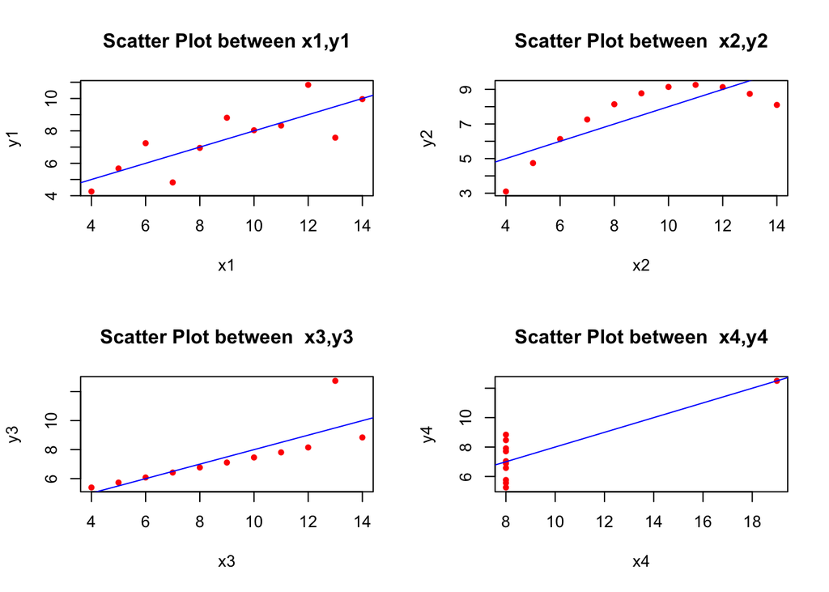

```r
par(mfrow= c(2,2))

plot(x1, y1, main = "Scatter Plot between x1,y1", pch = 20, col="red")
abline(lm_1, col = "blue")

plot(x2, y2, main = "Scatter Plot between  x2,y2", pch = 20, col="red")
abline(lm_2, col = "blue")

plot(x3, y3, main = "Scatter Plot between  x3,y3", pch = 20, col="red")
abline(lm_3, col = "blue")

plot(x4, y4, main = "Scatter Plot between  x4,y4", pch = 20, col="red")
abline(lm_4, col = "blue")
```

7. Now compare the model fits for each model object.

```r
anova(lm_1)
```

```r
anova(lm_2)
```

```r
anova(lm_3)
```

```r
anova(lm_4)
```

8. In text, summarize the lesson of Anscombe’s Quartet and what it says about the value of data visualization.

Summarize:

- Anscombe’s Quartet consists of four data set of similar kind of data.
- Each data set consists of eleven pairs of values for x and y.
- The summary statistics are almost similar for each column values and correlations.
- The four data set appear to be identical.
- Plots tells that each data has different story.

Concludes:

- Summary statistics may not tell us all stories about the data.
- Graphical representation or visualization of data can give us a more clear picture about data.
- Data visualization in form of graphical datasets is important.